# PHYS 10791: Introduction to Data Science

[figure not shown]

**Course instructors:**

[Prof. Rene Breton](http://www.renebreton.org) - Twitter [@BretonRene](https://twitter.com/BretonRene)  
[Dr. Marco Gersabeck](http://www.hep.manchester.ac.uk/u/gersabec) - Twitter [@MarcoGersabeck](https://twitter.com/MarcoGersabeck)

*Note: You are not expected to understand all the computer coding presented with the solutions. You should understand the mathematical concepts and be able to recover the results. We present the computer code so you can learn coding tricks (e.g. read data, compute useful values, fit and plot data) should you be interested.*

# Chapter 6 - Problem Sheet

## Problem 1

### Fitting a powerlaw model

The radio spectrum of most pulsars empirically follows a powerlaw relationship $F(\nu) = F_0 \nu^{\alpha}$, where $F(\nu)$ is the flux at a given frequency $\nu$ in GHz, $F_0$ is the flux at $1\,GHz$ and $\alpha$ is called the powerlaw index. It is common to recover the spectral parameters $F_0$ and $\alpha$ by fitting a straight line using a least-square method as seen in Chapter 5 to a $\log F(\nu)$ vs $log(\nu)$ plot instead due to the non-linear nature of the powerlaw (see the figure below).

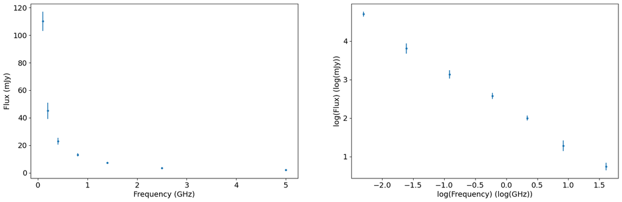

#### Task 1

Using the change of variables $y = \log(F(\nu))$ and $x = \log(\nu)$, show that the powerlaw model can be written as $y = mx + b$.

#### Task 2

Find an expression for the uncertainty on $y$, $\Delta y$, given that the fluxes have uncertainties $\Delta F$.

#### Task 3

Discuss the validity of the method of fitting a straight line to the log-log relationship. In particular, comment on what approximation is made and when it is no longer appropriate to use this method.

## Problem 2

### Random number generation

#### Task 1

Calculate the various modulous quantities:

a) $5 \operatorname{mod} 21$  
b) $1023 \operatorname{mod} 500$  
d) $83 \operatorname{mod} 15$  
d) $345 \operatorname{mod} 8943$

### Task 2

Given that the following sequence of pseudo-random numbers was produced with a linear congruential generator, provide the next 3 numbers in the sequence: {2, 5, 38, 54, 21, 89, 105, 2}.

## Problem 3

### Rejection sampling integration

Calculate the integral of $10 \cos (x \pi)$ in the range $x = [0, 0.5]$ using the rejection sampling integration. To do so, you will use a Monte Carlo with 10 draws generated with an linear congruential generator with modulus $m=89$, multiplier $a=3$ and increment $c=1$.

#### Task 2

Use the first 5 draws from above to create the sequence $x_i$ at which the function is evaluated. Show that the $x_i$ are {0.202, 0.112, 0.343, 0.034, 0.107}.

#### Task 3

Use the following 5 draws to generate your $r_i$ to decide if the ratio $f(x_i) / f_{\rm max}$ is accepted or not. Show that the $r_i$ are {0.652, 0.966, 0.910, 0.742, 0.236}.

#### Task 4

Calculate the integral using the rejection sampling.

#### Task 5

How does the value compare with the integral calculated analytically?

This work is licensed under a [Creative Commons Attribution-NonCommercial-ShareAlike 4.0 International License](http://creativecommons.org/licenses/by-nc-sa/4.0/)).

*Note: The content of this Jupyter Notebook is provided for educational purposes only.*